# Functions and Iteration

RAdelaide 2024

Author

Affiliation

Dr Stevie Pederson

Black Ochre Data Labs  
Telethon Kids Institute

Published

July 10, 2024

# Functions

## Functions

- Now familiar with using functions
- Writing our own functions is an everyday skill in `R`
- Sometimes complex $\implies$ usually *very simple*
- Mostly “inline” functions for simple data manipulation
  - Very common for axis labels in `ggplot()`

```r
library(tidyverse)
```

## A Quick Example

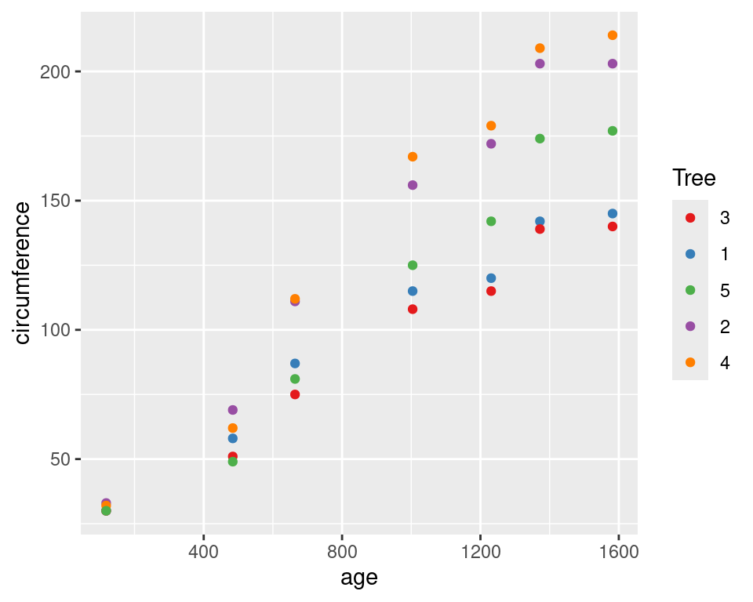

```r
Orange %>%
  ggplot(
    aes(
      age, circumference,
      colour = Tree
    )
  ) +
  geom_point() +
  scale_colour_brewer(
    palette = "Set1"
  )
```

. . .

- Let’s say that we wish to add the prefix ‘Tree’ to the legend

## A Quick Example

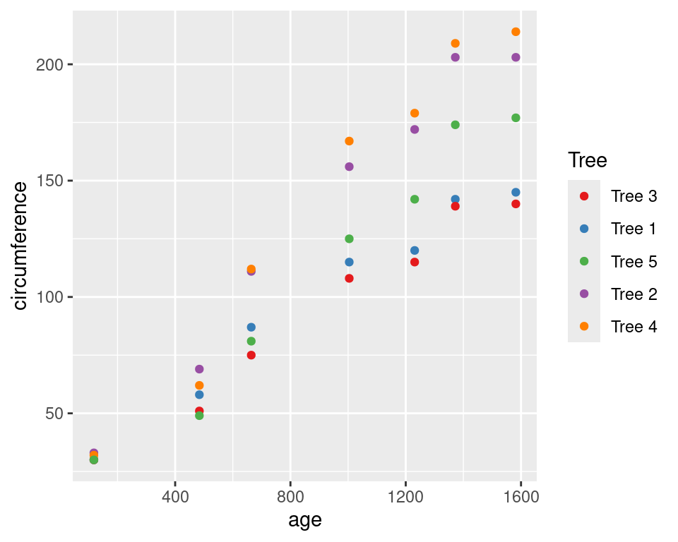

```r
Orange %>%
  ggplot(
    aes(
      age, circumference,
      colour = Tree
    )
  ) +
  geom_point() +
  scale_colour_brewer(
    palette = "Set1",
    labels = \(x) paste("Tree", x)
  )
```

. . .

- `\(x)` is shorthand for `function(x)` (since R v4.1)
- All labels are passed to the function as `x`
- New function notation was introduced in R v4.1 (2021)

## Inline Functions

- This is often referred to as an *inline function*
- Usually very simple, single line functions
  - Often `\(x)` using `x` as the underlying value
- We could’ve modified the underlying data (but didn’t)
- Also very useful when using `mutate()` to modify columns

## Inline Functions

- A common step I use when modifying labels might be

```r
flagstats <- c("properly_paired_reads", "unique_alignments")
flagstats %>%
  str_replace_all("_", " ") %>% # Add spaces
  str_to_title() %>% # Capitalise the 1st letter
  str_wrap(12) # Add line breaks (\n) to a given width
```

```
[1] "Properly\nPaired Reads" "Unique\nAlignments"
```

. . .

- When modifying x-axis labels this might lead to:

```r
scale_x_discrete(
  labels = \(x) x %>% str_replace_all("_", " ") %>% str_to_title() %>% str_wrap(12)
)
```

Piping like this is OK but up to you

## Understanding Functions

A function really has multiple aspects

1. The `formals()` $\implies$ the *arguments* we pass
2. The `body()` $\implies$ the code that does stuff
3. The `environment()` where calculations take place

Let’s look through `sd()` starting at the help page `?sd`

## Understanding Functions

```r
formals(sd)
```

```
$x


$na.rm
[1] FALSE
```

. . .

- These are the arguments (or formals) required by the function
- `na.rm` has a default value (`FALSE`)

## Understanding Functions

```r
body(sd)
```

```
sqrt(var(if (is.vector(x) || is.factor(x)) x else as.double(x),
    na.rm = na.rm))
```

. . .

Re-formatted that might be

```r
sqrt(
  var(
    if (is.vector(x) || is.factor(x)) x else as.double(x),
    na.rm = na.rm
  )
)
```

## Understanding Functions

So the full function might be written as:

```r
sd <- function(x, na.rm = FALSE) {
  sqrt(
    var(
      if (is.vector(x) || is.factor(x)) x else as.double(x),
      na.rm = na.rm
    )
  )
}
```

No need to write this function

## Understanding Functions

To make this more understandable

```r
sd <- function(x, na.rm = FALSE) {
  ## Coerce to a double, only if needed
  if (!is.vector(x) || is.factor(x)) x <- as.double(x)
  ## Calculate the variance
  var_x <- var(x, na.rm = na.rm)
  ## Return the square root of the variance
  sqrt(var_x)
}
```

## Writing Our Function

- Let’s write that function for modifying labels
- Start by deciding what the function might be called
  - Also what arguments we need

```r
modify_labels <- function(x) {

}
```

## Writing Our Function

- The first step is to change `"_"` to spaces
  - The last line will be returned by default

```r
modify_labels <- function(x) {
  str_replace_all(x, "_", " ")
}
modify_labels(flagstats)
```

```
[1] "properly paired reads" "unique alignments"
```

## Writing Our Function

- We’re going to modify that again $\implies$ let’s form an object
  - Then return the new object

```r
modify_labels <- function(x) {
  new_x <- str_replace_all(x, "_", " ")
  new_x
}
modify_labels(flagstats)
```

```
[1] "properly paired reads" "unique alignments"
```

## Looking Inside the Function

- Why are we referring to `flagstats` as `x`?

. . .

- When we pass it to the function is temporarily renamed `x`  
  $\implies$ *But where is it called x?*

. . .

- Each function has it’s own environment
  - Within the `GlobalEnvironment` but separate

## Looking Inside the Function

- If we add a `browser()` command, we can enter the function at that exact point

```r
modify_labels <- function(x) {
  browser()
  new_x <- str_replace_all(x, "_", " ")
  new_x
}
modify_labels(flagstats)
```

- You should have been jumped to the `Environnment` Tab
- The Console should also say `Browse[1]>`

This played up when testing both locally & on posit cloud

## Looking Inside the Function

- We’re now looking inside the environment within the function
- By passing `flagstats` as `x` $\implies$ this is it’s name **within** this environment
- Modifying *within the function* will not change the object in the *Global Environment*

. . .

- Within the browser execute  
  `new_x <- str_replace_all(x, "_", " ")`

. . .

- What happened?
- Should’ve seen the new object created in the function environment

## Writing Our Function

- Exit the `browser()` by typing `Q`
- Remove the `browser()` line by adding a comment (`#`) to the start

. . .

- Now we can finish the function

```r
modify_labels <- function(x) {
  # browser()
  new_x <- str_replace_all(x, "_", " ")
  new_x <- str_to_title(new_x)
  new_x <- str_wrap(new_x, 12)
  new_x
}
modify_labels(flagstats)
```

```
[1] "Properly\nPaired Reads" "Unique\nAlignments"
```

. . .

*Why didn’t I use a pipe?*

## Extending Our Function

- Can we also control the width at which the text wraps
  - Hard-wired to `12` internally

. . .

- Add an extra argument called `width` with default value of 12
  - Now this can be changed any time we call the function

```r
modify_labels <- function(x, width = 12) {
  # browser()
  new_x <- str_replace_all(x, "_", " ")
  new_x <- str_to_title(new_x)
  new_x <- str_wrap(new_x, width)
  new_x
}
modify_labels(flagstats)
```

```
[1] "Properly\nPaired Reads" "Unique\nAlignments"
```

```r
modify_labels(flagstats, 80)
```

```
[1] "Properly Paired Reads" "Unique Alignments"
```

## Extending Our Function

- In many help pages you may see `...` as a function argument
- This allows for passing arguments to internal functions
  - Are *not required* to be set specifically
- Check the help page `?str_wrap`

. . .

- Notice there are four additional arguments:
  - `width`, `indent`, `exdent` and `whitespace_only`

## Extending Our Function

- Let’s remove width from our list of formal arguments
- Replace with `...`
- Pass `...` inside `str_wrap`

```r
modify_labels <- function(x, ...) {
  # browser()
  new_x <- str_replace_all(x, "_", " ")
  new_x <- str_to_title(new_x)
  new_x <- str_wrap(new_x, ...)
  new_x
}
modify_labels(flagstats)
```

```
[1] "Properly Paired Reads" "Unique Alignments"
```

```r
modify_labels(flagstats, width = 12)
```

```
[1] "Properly\nPaired Reads" "Unique\nAlignments"
```

## Extending Our Function

- The default values will now be applied by `str_wrap()` *unless* we change them
- The following would indent the first line by 2 spaces
  - May be a little pointless …

```r
modify_labels(flagstats, width = 12, indent = 2)
```

```
[1] "  Properly\nPaired Reads" "  Unique\nAlignments"
```

. . .

- When writing functions need to choose target function carefully

## Finishing Our Function

- This is a more formal implementation of the original process
- These two are functionally identical
  - One more suited for *inline* use as a one-off
  - The other may be more useful if using repeatedly

```r
one_liner <- \(x, ...) x %>% str_replace_all("_", " ") %>% str_to_title() %>% str_wrap(...)
one_liner(flagstats, width = 12)
```

```
[1] "Properly\nPaired Reads" "Unique\nAlignments"
```

```r
modify_labels(flagstats, width = 12)
```

```
[1] "Properly\nPaired Reads" "Unique\nAlignments"
```

. . .

*What else could we have done?*

- Added comments to explain each line
- Added checks like `stopifnot(is.character(x))`

# Iteration

## Iteration

- `R` sees everything as vectors
- We didn’t need to modify each value of `flagstats`
  - Not the case for most languages
  - `python`, `C`, `C++`. `perl` etc *step* through vectors  
    $\implies$process one value at a time

## Iteration

- A python-like process might’ve been

```r
new_x <- c()
for (x in flagstats) {
  new_x <- c(new_x, modify_labels(x, width = 12))
}
new_x
```

```
[1] "Properly\nPaired Reads" "Unique\nAlignments"
```

. . .

1. We formed an empty object
2. Stepped through every value in flagstats
3. Modified values one at a time & added to `new_x`

. . .

*Stupidly slow in R*

## Iteration

- Each value was called `x` as we stepped through it
- `x` is just a convention $\implies$ can be anything (`i`, `bob` etc)

```r
for (x in flagstats) {
  print(x)
}
```

```
[1] "properly_paired_reads"
[1] "unique_alignments"
```

```r
for (i in flagstats) {
  print(i)
}
```

```
[1] "properly_paired_reads"
[1] "unique_alignments"
```

```r
for (bob in flagstats) {
  print(bob)
}
```

```
[1] "properly_paired_reads"
[1] "unique_alignments"
```

## Iteration

- Because `R` works on vectors $\implies$ rarely need to iterate on vectors

. . .

- Lists however…

. . .

- How would we get the length for each list element?

```r
vals <- list(letters = letters, num = rnorm(1000))
```

. . .

*Iteration is probably our first, best guess…*

## Iteration

```r
len <- list()
for (x in vals) {
  len <- c(len, length(x))
}
names(len) <- names(vals)
len
```

```
$letters
[1] 26

$num
[1] 1000
```

The above

1. Initialises an empty list `len`
2. Steps through each element calling it `x`
3. Finds the length of `x` and extends `len`
4. Adds the names so we know which value goes with which element

## The `R` Way to Iterate

- Conventional iteration is very slow in `R`
- Provides the function `lapply`
  - Stands for *list apply*
  - Applies a function to each element of a list

. . .

- Syntax is `lapply(list, function, ...)`

. . .

```r
lapply(vals, length)
```

```
$letters
[1] 26

$num
[1] 1000
```

- No `...` arguments needed here

Much simpler way to work & is faster

## The `R` Way to Iterate

A quick example using the `...`

```r
lapply(vals, head, n = 4)
```

```
$letters
[1] "a" "b" "c" "d"

$num
[1] -0.06136509  1.17332403 -1.37271761 -0.97836301
```

## The `R` Way to Iterate

- `lapply()` will always return a list
- Safest option
  - Calling `head` gave two elements of different types
  - Calling `length` gave two `integer` elements

. . .

- We could’ve coerced the lengths into a vector

```r
lapply(vals, length) %>% unlist()
```

```
letters     num
     26    1000
```

. . .

- Only useful *if returning a common type*

## The `R` Way to Iterate

- If we know what we’ll get$\implies$ `map_*()` functions
- Part of `purrr` $\implies$ core `tidyverse` package

```r
map_int(vals, length)
```

```
letters     num
     26    1000
```

. . .

- Alternatives are `map_chr()`, `map_lgl()`, `map_dbl()`
- Will error if setting the wrong type
- Only used when single values are returned

# Getting Real

## SNP Data

- For the rest of this session we’ll look at some genotype data
- Will put all the day’s material into practice
- Everyone will have very different applications
- Hopefully will help you figure out best approach for your data

. . .

- Simulated data
- Based on surviving moths after exposure to freezing temperature

## SNP Data

```r
snps <- read_csv("data/snps.csv")
dim(snps)
```

```
[1]  104 2001
```

```r
snps[1:6, 1:10]
```

```
# A tibble: 6 × 10
  Population SNP1  SNP2  SNP3  SNP4  SNP5  SNP6  SNP7  SNP8  SNP9
  <chr>      <chr> <chr> <chr> <chr> <chr> <chr> <chr> <chr> <chr>
1 Control    AB    BB    AB    BB    BB    BB    BB    AB    AB
2 Control    AB    AB    AB    AB    BB    <NA>  AA    AA    AB
3 Control    BB    AB    AA    AA    AA    AB    AB    BB    AB
4 Control    AB    AB    BB    AB    AB    AB    AA    AA    BB
5 Control    BB    BB    AB    BB    AB    AA    AA    AB    AB
6 Control    AB    AB    AA    AA    AB    <NA>  AB    BB    AB
```

. . .

- Each row represents a surviving moth
- We have 104 moths with 2000 SNP genotypes

## SNP Data

Our task is to:

- Perform Fisher’s Exact Test on each SNP locus
  - Tests for association between genotype and survival
  - Could be allele count or genotypes
  - Dominant or recessive model
- Decide which values to return
  - Probably a p-value
  - Do we want genotype counts? Odds Ratios?

. . .

- `lapply()` and functions will be our friends

## SNP Data

- First let’s check our population sizes

```r
snps %>% summarise(n = dplyr::n(), .by = Population)
```

```
# A tibble: 2 × 2
  Population     n
  <chr>      <int>
1 Control       53
2 Treat         51
```

## Missing Genotypes

- Check the missing genotypes

. . .

- Know we know functions $\implies$ `across()`
- Is a `dplyr` function
  - Enables us to apply a function *across* zero or more columns
  - Uses `tidyselect` helpers
- The help page has lots of information
  - Lets use it first

## Missing Genotypes

- Apply the function `is.na()` *across* all columns that *start_with* “SNP”

```r
snps %>%
  mutate(across(starts_with("SNP"), is.na)) %>%
  dplyr::select(1:10)
```

```
# A tibble: 104 × 10
   Population SNP1  SNP2  SNP3  SNP4  SNP5  SNP6  SNP7  SNP8  SNP9
   <chr>      <lgl> <lgl> <lgl> <lgl> <lgl> <lgl> <lgl> <lgl> <lgl>
 1 Control    FALSE FALSE FALSE FALSE FALSE FALSE FALSE FALSE FALSE
 2 Control    FALSE FALSE FALSE FALSE FALSE TRUE  FALSE FALSE FALSE
 3 Control    FALSE FALSE FALSE FALSE FALSE FALSE FALSE FALSE FALSE
 4 Control    FALSE FALSE FALSE FALSE FALSE FALSE FALSE FALSE FALSE
 5 Control    FALSE FALSE FALSE FALSE FALSE FALSE FALSE FALSE FALSE
 6 Control    FALSE FALSE FALSE FALSE FALSE TRUE  FALSE FALSE FALSE
 7 Control    FALSE FALSE FALSE FALSE FALSE FALSE FALSE FALSE FALSE
 8 Control    FALSE FALSE FALSE FALSE FALSE FALSE FALSE FALSE FALSE
 9 Control    FALSE FALSE FALSE FALSE FALSE FALSE FALSE FALSE FALSE
10 Control    FALSE FALSE FALSE FALSE FALSE FALSE FALSE FALSE FALSE
# ℹ 94 more rows
```

## Missing Genotypes

- If we pass to `summarise()` we can count these accross all SNPs
  - Perfect opportunity for an inline function

```r
snps %>%
  summarise(
    across(starts_with("SNP"), \(x) sum(is.na(x)))
  ) %>%
  dplyr::select(1:10)
```

```
# A tibble: 1 × 10
   SNP1  SNP2  SNP3  SNP4  SNP5  SNP6  SNP7  SNP8  SNP9 SNP10
  <int> <int> <int> <int> <int> <int> <int> <int> <int> <int>
1     3     0     1     0     2     3     1     1     1     1
```

## Missing Genotypes

- This gives the missing count for all 2000 loci
- Maybe `pivot_longer()` might help

```r
snps %>%
  summarise(
    across(starts_with("SNP"), \(x) sum(is.na(x)))
  ) %>%
  pivot_longer(everything(), names_to = "locus", values_to = "missing")
```

```
# A tibble: 2,000 × 2
   locus missing
   <chr>   <int>
 1 SNP1        3
 2 SNP2        0
 3 SNP3        1
 4 SNP4        0
 5 SNP5        2
 6 SNP6        3
 7 SNP7        1
 8 SNP8        1
 9 SNP9        1
10 SNP10       1
# ℹ 1,990 more rows
```

## Missing Genotypes

- Now we can summarise again
- Will make a nice descriptive table in our `rmarkdown` report

```r
snps %>%
  summarise(
    across(starts_with("SNP"), \(x) sum(is.na(x)))
  ) %>%
  pivot_longer(everything(), names_to = "locus", values_to = "missing") %>%
  summarise(n = dplyr::n(), .by = missing) %>%
  arrange(desc(n))
```

```
# A tibble: 7 × 2
  missing     n
    <int> <int>
1       1   721
2       0   706
3       2   361
4       3   164
5       4    39
6       5     8
7       6     1
```

## Performing an Analysis

- Let’s see if the `A` allele acts in a dominant manner
- Compare the numbers with A alleles across populations

. . .

- Classic Fisher’s Exact Test using a 2x2 table

|  | A_TRUE | A_FALSE |
| --- | --- | --- |
| Control | *a* | *b* |
| Treat | *c* | *d* |

. . .

- No right or wrong strategy

## Performing an Analysis

- Start by converting to long form

```r
snps %>%
  pivot_longer(starts_with("SNP"), names_to = "locus", values_to = "genotype")
```

. . .

- Can easily remove the missing genotypes

```r
snps %>%
  pivot_longer(starts_with("SNP"), names_to = "locus", values_to = "genotype") %>%
  dplyr::filter(!is.na(genotype))
```

## Performing an Analysis

- Check for the presence of an `A` allele

```r
snps %>%
  pivot_longer(starts_with("SNP"), names_to = "locus", values_to = "genotype") %>%
  dplyr::filter(!is.na(genotype)) %>%
  mutate(A = str_detect(genotype, "A"))
```

## Performing an Analysis

- Now count by presence of A
  - Set the grouping to be by Population, locus & `A` status

```r
snps %>%
  pivot_longer(starts_with("SNP"), names_to = "locus", values_to = "genotype") %>%
  dplyr::filter(!is.na(genotype)) %>%
  mutate(A = str_detect(genotype, "A")) %>%
  summarise(n = dplyr::n(), .by = c(Population, locus, A))
```

## Performing an Analysis

- Move the counts into `TRUE/FALSE` columns
  - The 2x2 tables now start to appear

```r
snps %>%
  pivot_longer(starts_with("SNP"), names_to = "locus", values_to = "genotype") %>%
  dplyr::filter(!is.na(genotype)) %>%
  mutate(A = str_detect(genotype, "A")) %>%
  summarise(n = dplyr::n(), .by = c(Population, locus, A)) %>%
  pivot_wider(
    names_from = "A", values_from = "n", values_fill = 0, names_prefix = "A_"
  ) %>%
  arrange(locus)
```

## Performing an Analysis

- We can form a nested `tibble` for each locus

```r
snps %>%
  pivot_longer(starts_with("SNP"), names_to = "locus", values_to = "genotype") %>%
  dplyr::filter(!is.na(genotype)) %>%
  mutate(A = str_detect(genotype, "A")) %>%
  summarise(n = dplyr::n(), .by = c(Population, locus, A)) %>%
  pivot_wider(
    names_from = "A", values_from = "n", values_fill = 0, names_prefix = "A_"
  ) %>%
  nest(df = c(Population, starts_with("A_")))
```

## Nesting Columns

- This is a new idea $\implies$ we now have a `list` column
- Look at the first one to see what the elements look like
  - Not part of the analysis

```r
snps %>%
  pivot_longer(starts_with("SNP"), names_to = "locus", values_to = "genotype") %>%
  dplyr::filter(!is.na(genotype)) %>%
  mutate(A = str_detect(genotype, "A")) %>%
  summarise(n = dplyr::n(), .by = c(Population, locus, A)) %>%
  pivot_wider(
    names_from = "A", values_from = "n", values_fill = 0, names_prefix = "A_"
  ) %>%
  nest(df = c(Population, starts_with("A_"))) %>%
  slice(1) %>% pull(df)
```

## Using `lapply()` On Nested Columns

- We can use `lapply()` to perform an analysis on every nested df

```r
snps %>%
  pivot_longer(starts_with("SNP"), names_to = "locus", values_to = "genotype") %>%
  dplyr::filter(!is.na(genotype)) %>%
  mutate(A = str_detect(genotype, "A")) %>%
  summarise(n = dplyr::n(), .by = c(Population, locus, A)) %>%
  pivot_wider(
    names_from = "A", values_from = "n", values_fill = 0, names_prefix = "A_"
  ) %>%
  nest(df = c(Population, starts_with("A_"))) %>%
  mutate(
    ft = lapply(df, \(x) fisher.test(x[, c("A_TRUE", "A_FALSE")]))
  )
```

## Using `lapply()` On Nested Columns

- We now have a new list column with a list of results from each test
- Objects of class `htest`
- Will have an element called `p.value`
- This is a `double` (i.e. `numeric`)

. . .

- We can use `map_dbl()` to grab these values

## Using `lapply()` On Nested Columns

```r
snps %>%
  pivot_longer(starts_with("SNP"), names_to = "locus", values_to = "genotype") %>%
  dplyr::filter(!is.na(genotype)) %>%
  mutate(A = str_detect(genotype, "A")) %>%
  summarise(n = dplyr::n(), .by = c(Population, locus, A)) %>%
  pivot_wider(
    names_from = "A", values_from = "n", values_fill = 0, names_prefix = "A_"
  ) %>%
  nest(df = c(Population, starts_with("A_"))) %>%
  mutate(
    ft = lapply(df, \(x) fisher.test(x[, c("A_TRUE", "A_FALSE")])),
    p = map_dbl(ft, \(x) x$p.value),
  )
```

## Using `lapply()` On Nested Columns

- How about an Odds Ratio?
  - The OR is in an element called `estimate`

. . .

```r
snps %>%
  pivot_longer(starts_with("SNP"), names_to = "locus", values_to = "genotype") %>%
  dplyr::filter(!is.na(genotype)) %>%
  mutate(A = str_detect(genotype, "A")) %>%
  summarise(n = dplyr::n(), .by = c(Population, locus, A)) %>%
  pivot_wider(
    names_from = "A", values_from = "n", values_fill = 0, names_prefix = "A_"
  ) %>%
  nest(df = c(Population, starts_with("A_"))) %>%
  mutate(
    ft = lapply(df, \(x) fisher.test(x[, c("A_TRUE", "A_FALSE")])),
    OR = map_dbl(ft, \(x) x$estimate),
    p = map_dbl(ft, \(x) x$p.value),
  )
```

## Using `lapply()` On Nested Columns

- Getting counts will require using `df` again

. . .

```r
snps %>%
  pivot_longer(starts_with("SNP"), names_to = "locus", values_to = "genotype") %>%
  dplyr::filter(!is.na(genotype)) %>%
  mutate(A = str_detect(genotype, "A")) %>%
  summarise(n = dplyr::n(), .by = c(Population, locus, A)) %>%
  pivot_wider(
    names_from = "A", values_from = "n", values_fill = 0, names_prefix = "A_"
  ) %>%
  nest(df = c(Population, starts_with("A_"))) %>%
  mutate(
    ft = lapply(df, \(x) fisher.test(x[, c("A_TRUE", "A_FALSE")])),
    Control = map_int(df, \(x) dplyr::filter(x, Population == "Control")[["A_TRUE"]]),
    Treat = map_int(df, \(x) dplyr::filter(x, Population == "Treat")[["A_TRUE"]]),
    OR = map_dbl(ft, \(x) x$estimate),
    p = map_dbl(ft, \(x) x$p.value),
  )
```

## The Final Analysis

```r
snps %>%
  pivot_longer(starts_with("SNP"), names_to = "locus", values_to = "genotype") %>%
  dplyr::filter(!is.na(genotype)) %>%
  mutate(A = str_detect(genotype, "A")) %>%
  summarise(n = dplyr::n(), .by = c(Population, locus, A)) %>%
  pivot_wider(
    names_from = "A", values_from = "n", values_fill = 0, names_prefix = "A_"
  ) %>%
  nest(df = c(Population, starts_with("A_"))) %>%
  mutate(
    ft = lapply(df, \(x) fisher.test(x[, c("A_TRUE", "A_FALSE")])),
    Control = map_int(df, \(x) dplyr::filter(x, Population == "Control")[["A_TRUE"]]),
    Treat = map_int(df, \(x) dplyr::filter(x, Population == "Treat")[["A_TRUE"]]),
    OR = map_dbl(ft, \(x) x$estimate),
    p = map_dbl(ft, \(x) x$p.value),
    adj_p = p.adjust(p, "bonferroni")
  ) %>%
  arrange(p)
```

```
# A tibble: 2,000 × 8
   locus   df               ft      Control Treat    OR        p    adj_p
   <chr>   <list>           <list>    <int> <int> <dbl>    <dbl>    <dbl>
 1 SNP1716 <tibble [2 × 3]> <htest>      47     8  38.7 2.17e-14 4.35e-11
 2 SNP1236 <tibble [2 × 3]> <htest>      46    11  22.9 1.29e-11 2.57e- 8
 3 SNP1618 <tibble [2 × 3]> <htest>      45    12  22.7 3.00e-11 6.00e- 8
 4 SNP248  <tibble [2 × 3]> <htest>      44    10  18.8 7.91e-11 1.58e- 7
 5 SNP1730 <tibble [2 × 3]> <htest>      43    10  17.0 3.27e-10 6.54e- 7
 6 SNP311  <tibble [2 × 3]> <htest>      41    10  13.5 2.52e- 9 5.04e- 6
 7 SNP1385 <tibble [2 × 3]> <htest>      45    14  14.0 3.70e- 9 7.40e- 6
 8 SNP1647 <tibble [2 × 3]> <htest>      43    13  13.5 4.28e- 9 8.57e- 6
 9 SNP8    <tibble [2 × 3]> <htest>      46    16  13.5 9.41e- 9 1.88e- 5
10 SNP1993 <tibble [2 × 3]> <htest>      40    11  11.7 1.74e- 8 3.47e- 5
# ℹ 1,990 more rows
```

For those with an OR > 1 the A allele might be a dominant susceptibility locus

## Summary

- We could save this as a final object
- Select our important columns and prepare a table

## Summary

For this we needed to understand

- When to use `pivot_longer()` and `pivot_wider()`
- What is a `list`, `vector` and `data.frame`?
- Difference between `integer` and `double` values
- `tidyselect` helper functions + `dplyr`
- How to use `lapply()` with inline functions
- Extending `lapply()` using `map_*()` to produce vector output

## Summary

- Alternatives to `map_*()` are `sapply()` and `vapply()`
  - `sapply()` is slightly unpredictable
  - `vapply()` is a bit more clunky but powerful

. . .

- Could’ve use `unlist(lapply(...))`

*Why didn’t we?*

Specifying the exact type will error if we’re wrong. This is good